# TIME SERIES MODEL-SRIMA - Seasonal Box-Jenkins Models(SARIMA)

### Importing Libraries

```r
library(forecast)
library(urca)    #for DF test
```

### Importing the data

```r
cropdata<-read.csv("CROP DATA.csv",header=T)
head(cropdata)
```

```
  Year Quarter CROPYIELD
1 1947       1  2182.681
2 1947       2  2176.892
3 1947       3  2172.432
4 1947       4  2206.452
5 1948       1  2239.682
6 1948       2  2276.690
```

### Step One: Stationarity Checking

#### Plot Time Series and ACF

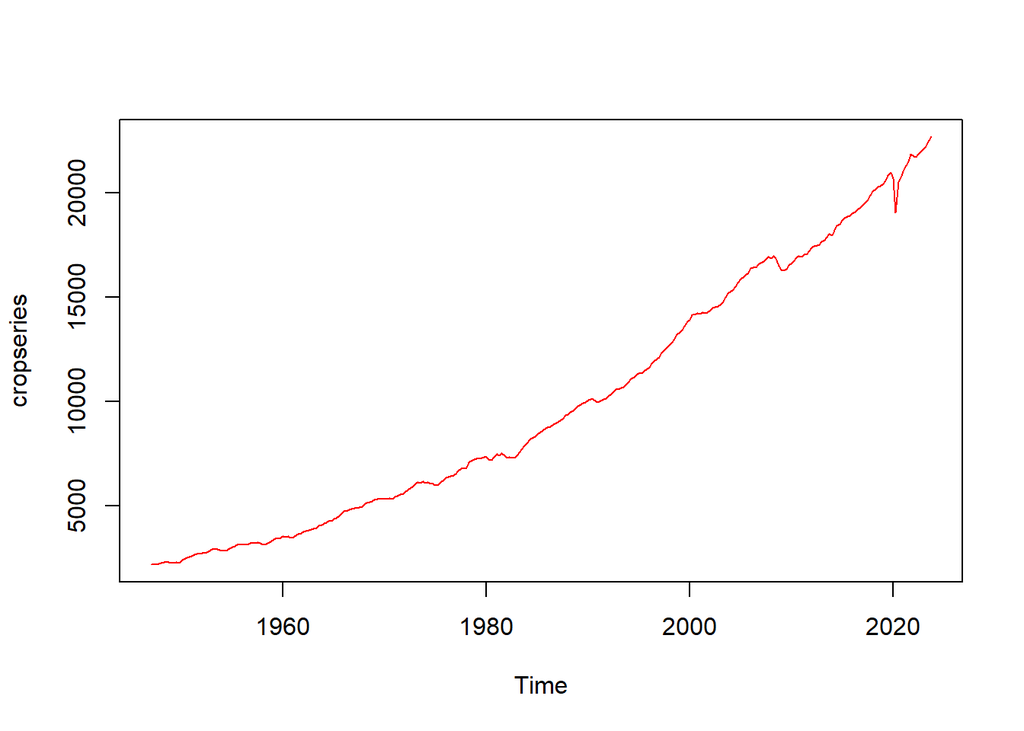

```r
cropseries<-ts(cropdata$CROPYIELD, start = 1947, end = 2024, frequency = 4)
cropseries<-head(cropseries,-1)

plot(cropseries,col="red")
```

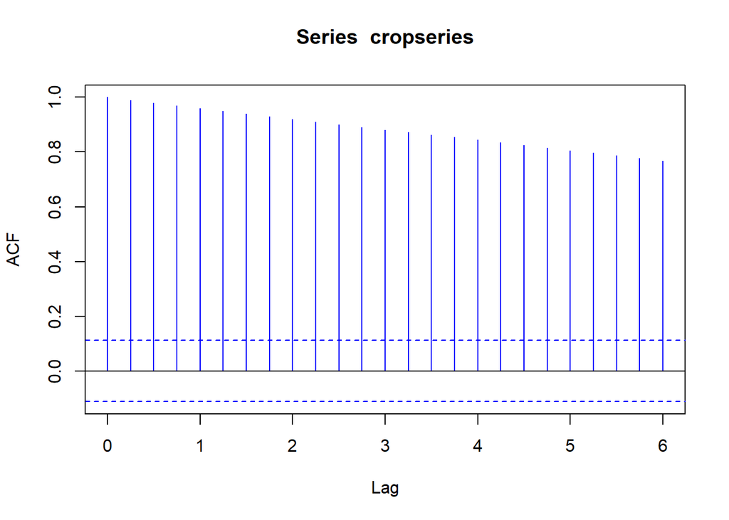

```r
acf(cropseries,col="blue")
```

**Inference**: We can see a very slow decay. Hence, it’s a sign of non-stationary

**Dickey Fuller Test to check for stationarity**

```r
summary(ur.df(cropseries,lag=0))
```

```
###############################################
# Augmented Dickey-Fuller Test Unit Root Test #
###############################################

Test regression none


Call:
lm(formula = z.diff ~ z.lag.1 - 1)

Residuals:
     Min       1Q   Median       3Q      Max
-1755.93   -21.13    11.85    49.04  1361.63

Coefficients:
         Estimate Std. Error t value Pr(>|t|)
z.lag.1 0.0060586  0.0007327   8.268  4.2e-15 ***
---
Signif. codes:  0 '***' 0.001 '**' 0.01 '*' 0.05 '.' 0.1 ' ' 1

Residual standard error: 149 on 306 degrees of freedom
Multiple R-squared:  0.1826,    Adjusted R-squared:  0.1799
F-statistic: 68.37 on 1 and 306 DF,  p-value: 4.195e-15


Value of test-statistic is: 8.2684

Critical values for test statistics:
      1pct  5pct 10pct
tau1 -2.58 -1.95 -1.62
```

**Inference**: The value of the test statistic is: **8.2684**, which is greater than 5% critical value. Hence, Time series is non-stationary.

#### How Many Times Should Time Series Be Differenced to Make Stationary?

```r
ndiffs(cropseries)
```

```
[1] 2
```

Timeseries should be differenced 2 time to achieve stationarity.

#### Checking whether stationarity is achieved after differencing

```r
cropdiff<-diff(cropseries,differences=2)
summary(ur.df(cropdiff,lag=0))  #DF-test
```

```
###############################################
# Augmented Dickey-Fuller Test Unit Root Test #
###############################################

Test regression none


Call:
lm(formula = z.diff ~ z.lag.1 - 1)

Residuals:
     Min       1Q   Median       3Q      Max
-1576.48   -42.34     0.32    40.23  2365.20

Coefficients:
        Estimate Std. Error t value Pr(>|t|)
z.lag.1 -1.55195    0.04784  -32.44   <2e-16 ***
---
Signif. codes:  0 '***' 0.001 '**' 0.01 '*' 0.05 '.' 0.1 ' ' 1

Residual standard error: 187.9 on 304 degrees of freedom
Multiple R-squared:  0.7759,    Adjusted R-squared:  0.7751
F-statistic:  1052 on 1 and 304 DF,  p-value: < 2.2e-16


Value of test-statistic is: -32.4383

Critical values for test statistics:
      1pct  5pct 10pct
tau1 -2.58 -1.95 -1.62
```

**Inference**: The value of the test statistic is: **-32.4383**, which is less than 5% critical value. Hence, Stationarity is achieved with second order difference.

### Step Two: Model Identification

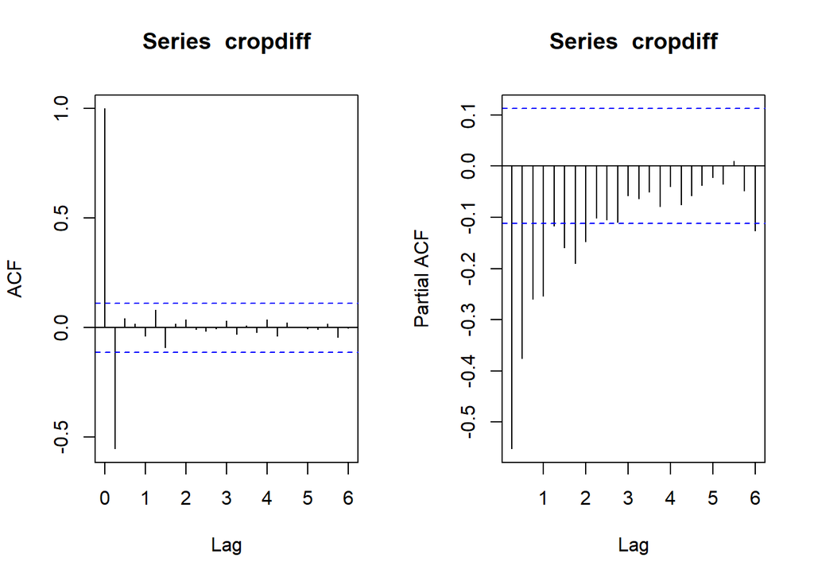

```r
par(mfrow = c(1, 2))
acf(cropdiff)
pacf(cropdiff)
```

### Step Three: Parameter Estimation

```r
cropmodel<-auto.arima(cropseries,d=2,D=1,max.p=2,max.q=2,max.P=1,max.Q=1,
trace=TRUE,ic="aic")
```

```
 Fitting models using approximations to speed things up...

 ARIMA(2,2,2)(1,1,1)[4]                    : 3845.97
 ARIMA(0,2,0)(0,1,0)[4]                    : 4292.328
 ARIMA(1,2,0)(1,1,0)[4]                    : 4074.6
 ARIMA(0,2,1)(0,1,1)[4]                    : 3861.55
 ARIMA(2,2,2)(0,1,1)[4]                    : 3835.627
 ARIMA(2,2,2)(0,1,0)[4]                    : Inf
 ARIMA(2,2,2)(1,1,0)[4]                    : Inf
 ARIMA(1,2,2)(0,1,1)[4]                    : Inf
 ARIMA(2,2,1)(0,1,1)[4]                    : 3850.56
 ARIMA(1,2,1)(0,1,1)[4]                    : 3846.207

 Now re-fitting the best model(s) without approximations...

 ARIMA(2,2,2)(0,1,1)[4]                    : Inf
 ARIMA(2,2,2)(1,1,1)[4]                    : Inf
 ARIMA(1,2,1)(0,1,1)[4]                    : Inf
 ARIMA(2,2,1)(0,1,1)[4]                    : Inf
 ARIMA(0,2,1)(0,1,1)[4]                    : Inf
 ARIMA(1,2,0)(1,1,0)[4]                    : 4140.812

 Best model: ARIMA(1,2,0)(1,1,0)[4]
```

```r
#### Display coefficients
cropmodel
```

```
Series: cropseries
ARIMA(1,2,0)(1,1,0)[4]

Coefficients:
          ar1     sar1
      -0.5781  -0.5336
s.e.   0.0469   0.0482

sigma^2 = 50442:  log likelihood = -2067.41
AIC=4140.81   AICc=4140.89   BIC=4151.94
```

Smaller the AIC value, better is the model. auto.arima tries out various combinations of AR and MA terms to arrive at final model. **Best model: ARIMA(1,2,0)(1,1,0)[4]**

### Step Four: Diagnostic Checking

```r
resi<-residuals(cropmodel)
Box.test(resi)
```

```
    Box-Pierce test

data:  resi
X-squared = 14.136, df = 1, p-value = 0.0001701
```

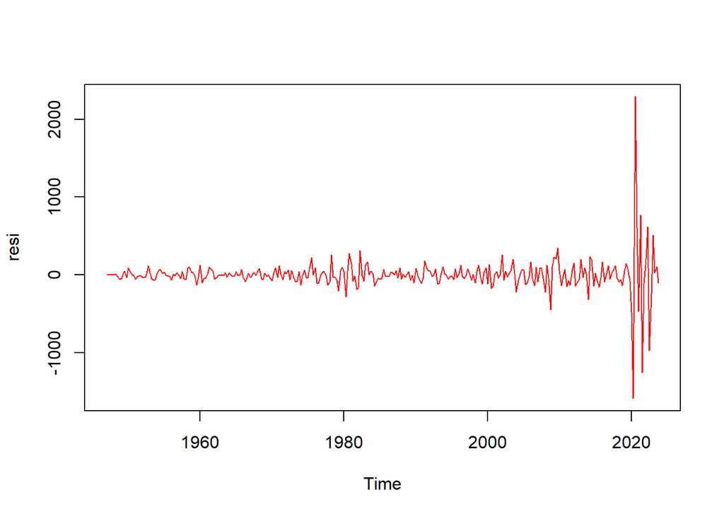

```r
plot(resi,col="red")
```

**Note:** Based on the Box-Pierce test result and the small p-value, it is likely that the residuals are not white noise, and there is evidence of autocorrelation in the model residuals. However, the white noise test is influenced by year 2020. Therefore, we have performed white noise test on recent 3 years residuals. In recent 3 years the residuals are:

```r
crop_resi_2021to2023<- tail(cropmodel$residuals,12)
crop_resi_2021to2023
```

```
            Qtr1        Qtr2        Qtr3        Qtr4
2021  -468.30283   767.51707 -1253.99630  -107.68595
2022   207.19446   612.40141  -970.88398  -237.37903
2023   511.58103    27.59923   106.28718  -100.93536
```

```r
Box.test(crop_resi_2021to2023)
```

```
    Box-Pierce test

data:  crop_resi_2021to2023
X-squared = 1.8791, df = 1, p-value = 0.1704
```

Inference: p-value is 0.1704, there is no significant autocorrelation in the residuals.

### Step Five: Forecasting

Making predictions for four quarters of 2024

```r
predict(cropmodel,n.ahead=4)
```

```
$pred
         Qtr1     Qtr2     Qtr3     Qtr4
2024 22695.17 22696.14 22896.96 23034.10

$se
         Qtr1     Qtr2     Qtr3     Qtr4
2024 224.5940 390.4238 625.8742 877.8843
```

**Inference**: Forecasted values for CropYeild 2024 - quarters are:  
**Qtr1**: 22695.17  
**Qtr2**: 22696.14  
**Qtr3**: 22896.96  
**Qtr4**: 23034.10